# Représentation des stats calculées par MetHis

## Librairies utilisées

```r
library(stringr)
library(ggplot2)
require(MASS)
```

## Vérification des priors utilisés

Fonction

```r
#Data frame prior
data.frame.prior = function(seq_ne, max_gen, max_simu){

  #Créer matrice vide qui contiendra les stats
  mat_prior = matrix(data = NA, nrow = length(seq_ne)*max_gen*max_simu, ncol = 5)
  #Attribution nom colonnes selon appelation stat par MetHis
  colnames(mat_prior) = c("Ne", "gen", "simu", "s1", "s2")
  mat_prior = as.data.frame(mat_prior)
  #Compteur pour indiquer les lignes à remplir
  cpt = 0

  for (ne in seq_ne) {
    dir_ne = str_c("Ne", toString(ne), "/") #Répertoire de taille effective
    row_min = cpt*max_gen*max_simu+1
    row_max = (cpt+1)*max_gen*max_simu
    mat_prior[row_min:row_max,1] = toString(ne)
    cpt = cpt+1

    for (nb_gen in 1:max_gen) {
      dir_gen = str_c("gen", toString(nb_gen), "/")
      row_min_gen = (nb_gen-1)*max_simu+1 + row_min
      row_max_gen = nb_gen*max_simu + row_min
      mat_prior[row_min_gen:row_max_gen,2] = nb_gen

      for (nb_simu in 1:max_simu) {
        mat_prior[row_min_gen+nb_simu-1,3] = nb_simu
        dir_simu = str_c("simu_", toString(nb_simu), "/")
        file_path = str_c(dir_ne, dir_gen, dir_simu, "simu_", nb_simu, ".txt")
        df_tmp = read.table(file_path, header = TRUE)
        mat_prior[row_min_gen+nb_simu-1,4:5] = df_tmp[1,5:6]

      }
    }
  }


  #Passage des Ne en facteur
  mat_prior$Ne = factor(as.factor(mat_prior$Ne), levels = as.character(seq_ne))
  #Passage générations en entier
  mat_prior$gen = as.integer(mat_prior$gen)
  #Passage simuulations en entier
  mat_prior$simu = as.integer(mat_prior$simu)

  return(mat_prior)
}
```

Application

```r
seq_64_8192 = 2**seq(6,13,1)
mat_prior_64_8192 = data.frame.prior(seq_64_8192, 100, 100)
summary(mat_prior_64_8192$s1[which(mat_prior_64_8192$Ne == "8192")])
```

```
##      Min.   1st Qu.    Median      Mean   3rd Qu.      Max.
## 0.0001087 0.2497484 0.5064564 0.5016643 0.7502090 0.9996677
```

## Résumé des lectures de stat

```bash
#Script bash pour réduire le nombre d'ouvertures de fichier en R.
#Attention !!! Script à utiliser s'il y a de nouvelles simulations
#et doit être modifié si de nouveaux sous-répertoires sont ajoutés
#2 lignes à ajouter dans ce cas : "cd $path_to_directory" et "set_resum_stat"
#Ne pas utiliser si répertoire cloné du github

set_resum_stat()
{
  list_Ne=$(ls -d Ne*)

  for Ne in $list_Ne; do
      cd $Ne
      list_gen=$(ls -d gen*)
      for gen in $list_gen; do
          cd $gen
          cat simu_*/final_sumstats.txt > tmp.txt
          nl tmp.txt | sort --key 2 --unique | sort --key 1 --numeric-sort > final_sumstats.txt
          rm tmp.txt
          cd ../
      done
      cd ../
  done
}

set_resum_stat

#cd ../old_methis_pop_increase
#set_resum_stat
```

Chaque répertoire correspondant à un effectif efficace Ne contient autant de sous-répertoires qu’il y a de générations (ici 100 générations). Chaque répertoire correspondant à une génération contient autant de sous-répertoires qu’il y a de simulations (ici 100 aussi). Enfin, dans chaque sous répertoire de simulations, on trouve un fichier “final_sumstats.txt” donnant les statistiques résumées de la simulation concernée.

On choisit donc ici : - de concaténer pour chaque génération de chaque effectif efficace l’ensemble des statistiques calculées sur les x simulations (bash) - de calculer la moyenne pour chaque statistique sur l’ensemble des simulations, ce qui correspondra aux statistiques pour la génération donnée - on peut ensuite observer une statistique choisie en fonction des générations, pour observer l’évolution de cet indicateur au cours du temps.

La fonction décrite ci-dessus respecte donc ce schéma, en enregistrant les données dans une matrice à 62 colonnes, avec l’effectif efficace sur la première colonne, la génération sur la deuxième, et les statistiques sur les colonnes 3 à 62.

## Fonctions utilisées

```r
#Data frame construction
data.frame.stat = function(seq_ne, max_gen){

  #Créer matrice vide qui contiendra les stats
  mat_stat = matrix(data = NA, nrow = length(seq_ne)*max_gen, ncol = 62)
  #Compteur pour indiquer les lignes à remplir
  cpt = 0

  for (ne in seq_ne) {
    dir_ne = str_c("Ne", toString(ne), "/") #Répertoire de taille effective
    row_min = cpt*100+1                     #Ligne min. où on écrit les stats pour le Ne donné
    row_max = (cpt+1)*100                   #Ligne max. où on écrit les stats
    mat_stat[row_min:row_max,1] = toString(ne) #Ecriture du Ne correspondant pour les stats qui seront écrites
    cpt = cpt+1                             #Incrémentation du compteur

    for (nb_gen in 1:max_gen) {
      dir_gen = str_c("gen", toString(nb_gen), "/") #Répertoire de génération
      mat_stat[row_min+nb_gen-1,2] = nb_gen         #Ecriture génération correspondante
      file_path = str_c(dir_ne, dir_gen, "final_sumstats.txt")
      file_stat = read.table(file_path, header = TRUE) #Lecture fichier stat résumées
      #Suppression 1ère colonne, contenant uniquement chiffres pour tri en bash.
      #+ calcul de la moyenne pour chaque stat, écrites dans la matrice
      file_stat = apply(file_stat[,-1], 2, mean)
      mat_stat[row_min+nb_gen-1,3:62] = file_stat
    }
  }

  #Passage de la matrice en data frame pour ggplot
  mat_stat = as.data.frame(mat_stat)
  #Attribution nom colonnes selon appelation stat par MetHis
  colnames(mat_stat) = c("Ne", "gen", names(file_stat))
  #Passage des Ne en facteur
  mat_stat$Ne = factor(as.factor(mat_stat$Ne), levels = as.character(seq_ne))
  #Passage générations en entier
  mat_stat$gen = as.integer(mat_stat$gen)
  #Passage stats en double
  for (numcol in 3:ncol(mat_stat)) {
    mat_stat[,numcol] = as.double(mat_stat[,numcol])
  }

  return(mat_stat)
}
```

```r
#Plot function
#Affichage d'une stat au cours des générations
plot_stat_gen = function(df, gen, stat, Ne, titre, ligne = FALSE){
  p = ggplot(df, aes(x = gen, y = stat, color = Ne)) + ggtitle(titre)
  if (ligne) {
    p = p + geom_point(size = 1)+ geom_line()
  }else{
    #smooth de la courbe pour obtenir régression et tempérer variabilité due au TCL
    p = p + geom_point(size = 1)+ geom_smooth()
  }
  print(p)
}
```

```r
extract_sub_mat = function(all_mat, list_ne){
  all_rows = c()
  for (ne in as.character(list_ne)) {
    all_rows = append(all_rows, which(all_mat[,1] == ne))
  }
  return(all_mat[all_rows,])
}
```

## Population constante de tailles initiales différentes

Calcul des matrices de stats

```r
seq_64_8192 = 2**seq(6,13,1)
seq_60_100 = 10*seq(5,10,1)
seq_tot = sort(c(seq_60_100, seq_64_8192))

mat_tot = data.frame.stat(seq_tot, 100)
mat_60_100 = extract_sub_mat(mat_tot, seq_60_100)
mat_64_8192 = extract_sub_mat(mat_tot, seq_64_8192)
```

Graphiques obtenus

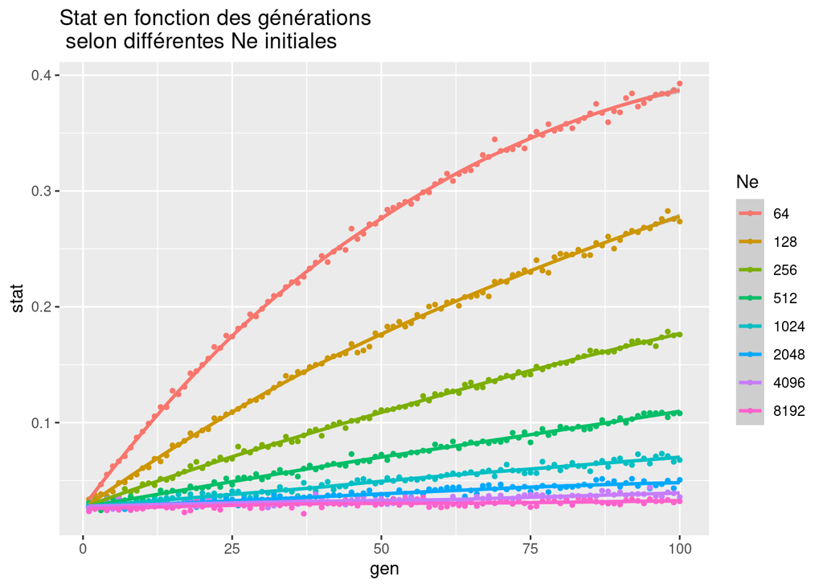

```r
plot_stat_gen(mat_64_8192, mat_64_8192$gen,
              mat_64_8192$Fst.s1.adm, mat_64_8192$Ne,
              "Stat en fonction des générations\n selon différentes Ne initiales")
```

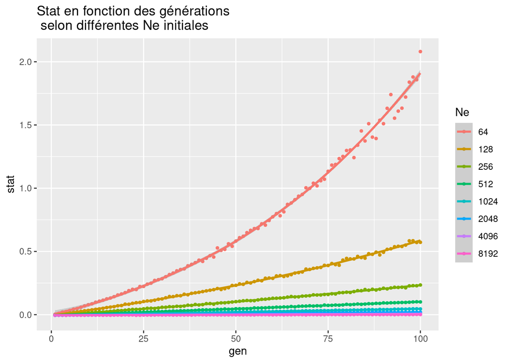

```r
plot_stat_gen(mat_64_8192, mat_64_8192$gen,
              mat_64_8192$f3, mat_64_8192$Ne,
              "Stat en fonction des générations\n selon différentes Ne initiales")
```

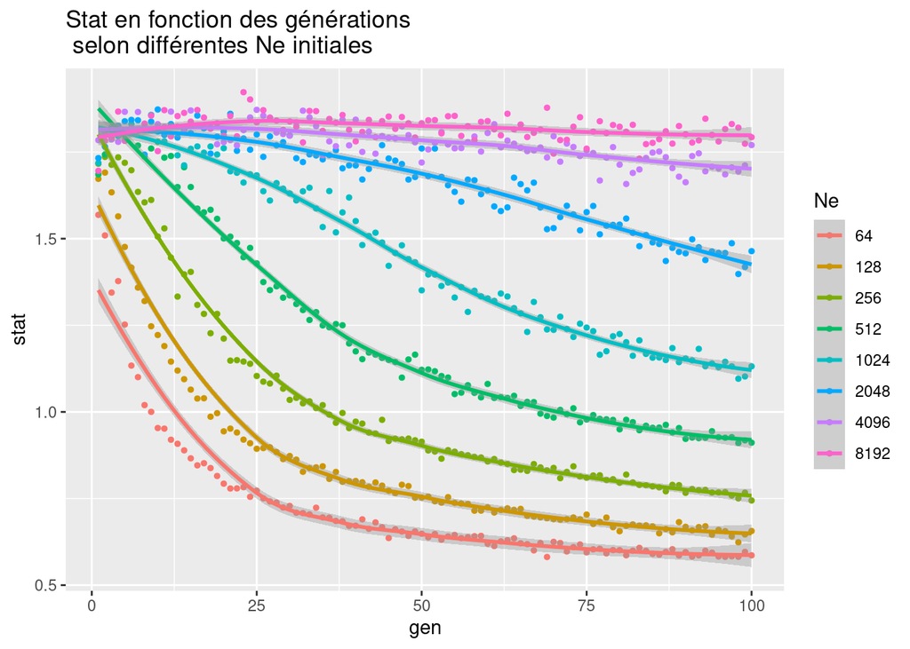

```r
plot_stat_gen(mat_64_8192, mat_64_8192$gen,
              mat_64_8192$mean.adm.angles, mat_64_8192$Ne,
              "Stat en fonction des générations\n selon différentes Ne initiales")
```

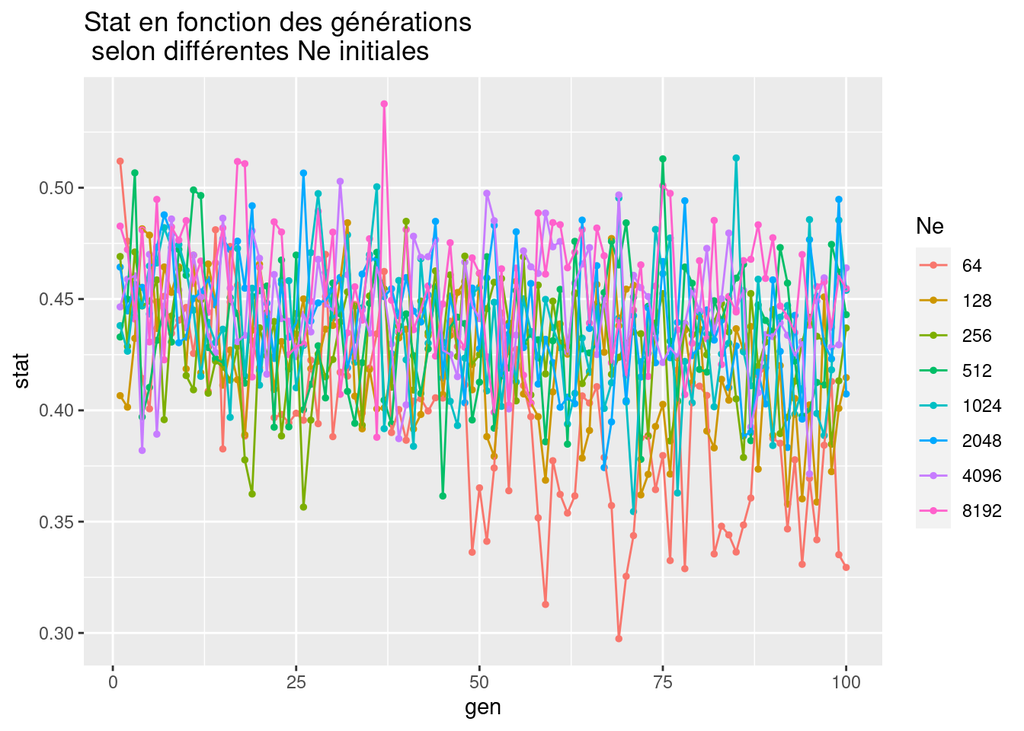

```r
plot_stat_gen(mat_64_8192, mat_64_8192$gen,
              mat_64_8192$mean.adm.props, mat_64_8192$Ne,
              "Stat en fonction des générations\n selon différentes Ne initiales", TRUE)
```

## Populations croissantes avec des N0 variant entre 30 et 110, et des Ng variant entre 100 et 8100.

Calcul des matrices

```r
setwd("../old_methis_pop_increase/")
seq_tot = c()
for (i in seq(30,110, by = 20)) {
  for (j in c(0:4)) {
    seq_tot = append(seq_tot, str_c(i, "-", 100*(3**j)))
  }
}
seq_tot = seq_tot[-which(seq_tot == "110-100")]
seq_end_900 = seq_tot[which(str_detect(seq_tot, "-900"))]
seq_end_8100 = seq_tot[which(str_detect(seq_tot, "-8100"))]
seq_start_30 = seq_tot[which(str_detect(seq_tot, "30-"))]

mat_tot = data.frame.stat(seq_tot, 100)
mat_end_900 = extract_sub_mat(mat_tot, seq_end_900)
mat_end_8100 = extract_sub_mat(mat_tot, seq_end_8100)
mat_start_30 = extract_sub_mat(mat_tot, seq_start_30)
```

Graphiques obtenus)

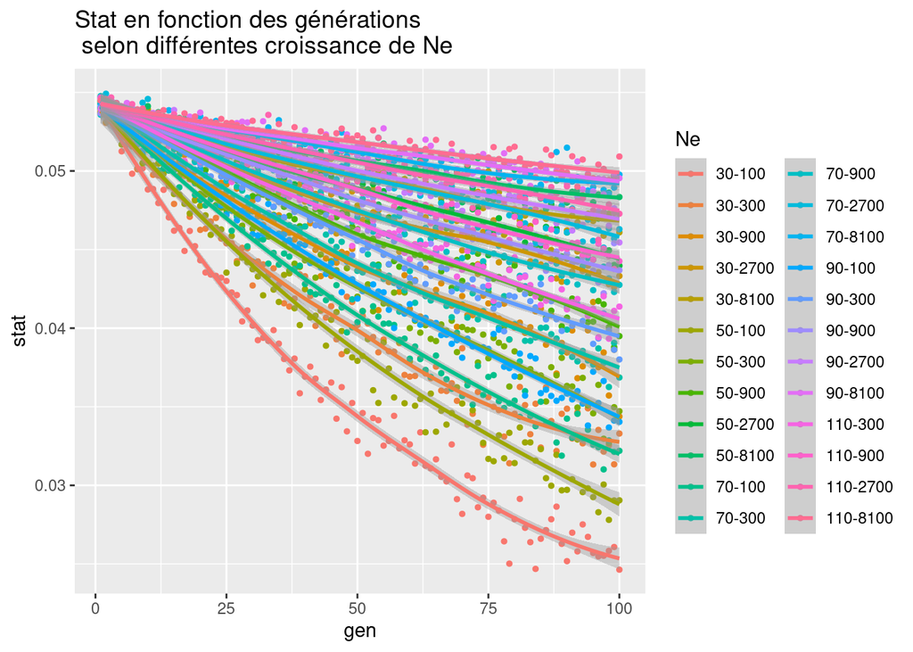

```r
plot_stat_gen(mat_tot, mat_tot$gen,
              mat_tot$mean.het.adm, mat_tot$Ne,
              "Stat en fonction des générations\n selon différentes croissance de Ne")
```

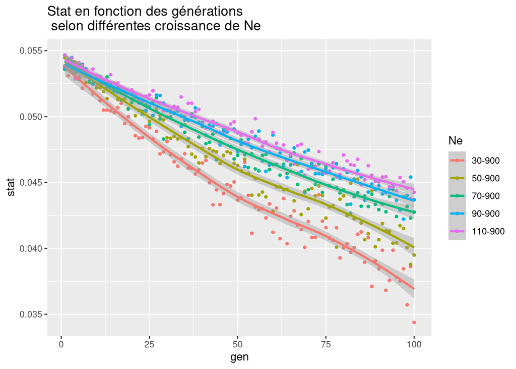

```r
plot_stat_gen(mat_end_900, mat_end_900$gen,
              mat_end_900$mean.het.adm, mat_end_900$Ne,
              "Stat en fonction des générations\n selon différentes croissance de Ne")
```

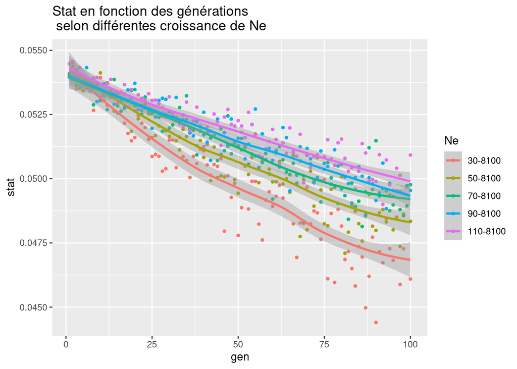

```r
plot_stat_gen(mat_end_8100, mat_end_8100$gen,
              mat_end_8100$mean.het.adm, mat_end_8100$Ne,
              "Stat en fonction des générations\n selon différentes croissance de Ne")
```

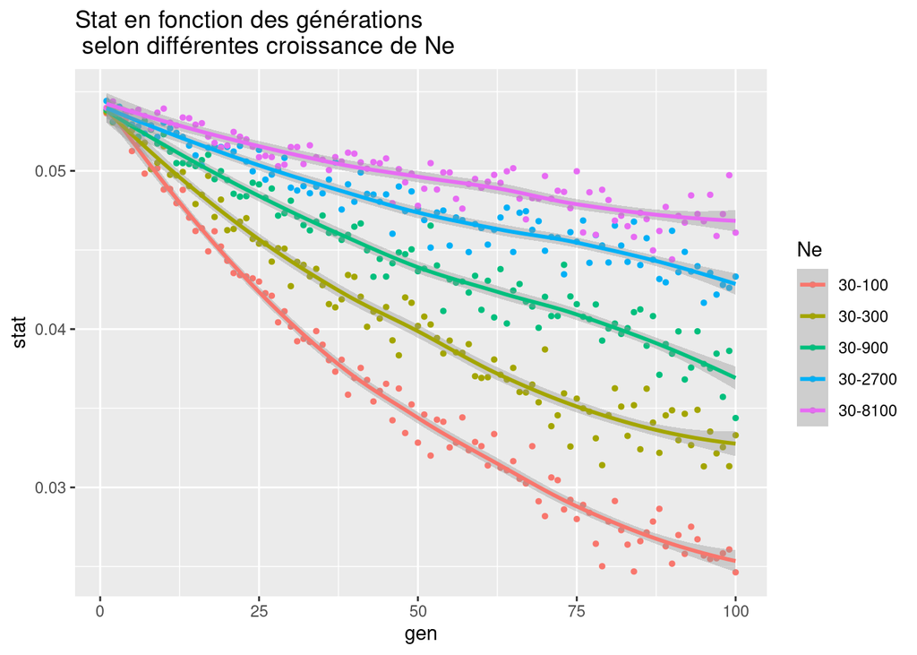

```r
plot_stat_gen(mat_start_30, mat_start_30$gen,
              mat_start_30$mean.het.adm, mat_start_30$Ne,
              "Stat en fonction des générations\n selon différentes croissance de Ne")
```